# Google capstone project report

Ajiboye Abeeb

2023-01-14

# Introduction

Cyclistic launched a successful bike-share program in 2016. Since then, the program has grown to a fleet of 5,824 geotracked bicycles that are locked into a network of 692 stations throughout Chicago. The bikes can be unlocked at any time from any station and returned to any other station in the system.

This is my first case study as a data analyst, and it is part of the Google Data Analytics Certificate optional Course capstone project.

The goal is to analyze a 12-month dataset for Cyclistic, a fictional bike sharing company, in order to gain insight for a marketing campaign.

In order to properly analyze these data in order to answer the key business questions and make recommendations, I will follow the key steps of Data Analysis Process: Ask, Prepare, Process, Analyze, Share and Act

[figure not shown]

**Scenerio**

I am a junior data analyst on the marketing analyst team at Cyclistic, a Chicago-based bike-share company. The marketing director believes that increasing the number of annual memberships is critical to the company’s future success. As a result, my team is interested in learning how casual riders and annual members use Cyclistic bikes differently.

My team will develop a new marketing strategy based on these findings in order to convert casual riders into annual members. However, Cyclistic executives must first approve my recommendations, which must be supported by compelling data insights and professional data visualizations.

# I. ASK

**a. Business task**

The objective is to convert casual riders to annual members in order to increase company profitability.

**b. Business Task for Junior Analyst**

As the company’s junior analyst, I’ve been tasked with demonstrating the following insight using the dataset: * How casual riders and annual members ride Cyclistic bikes differently.

**c. Key Stakeholders**

Project stakeholders include:

- Lily Moreno, Director of Marketing at Cyclistic, is in charge of the company’s marketing campaigns.
- The marketing analytics team at Cyclistic. This team is in charge of gathering, analyzing, and reporting data for use in marketing campaigns. This team’s junior analyst is me.
- The Cyclistic management team. This group makes the final call on the recommended marketing strategy. They are well-known for their attention to detail.

# II. PREPARE

**Where Can I Find the Data?**

The data is available [here](https://divvy-tripdata.s3.amazonaws.com/index.html). Motivate International Inc. gathered and uploaded the data.

**The Data’s Credibility**

Motivate, Inc., the company that manages the City of Chicago’s Cyclistic Bike Share program, collects the data directly. It is comprehensive and up to date because it is collected monthly, with the most recent data uploaded in January 2023.

**Authorization, Privacy, Security, and Accessibility**

The data is released under the terms of this [license](https://ride.divvybikes.com/data-license-agreement)

The data does not contain any personally identifiable information about the riders, so it is secure and open to the public.

**A. Data Credibility and Integrity Assessment**

I will use the ROCCC (Reliable, Original, Comprehensive, Current, and Cited) data test model to determine the dataset’s credibility and reliability.

- Reliable — MEDIUM — Fairly reliable because it attracts a large number of users
- Original — HIGH — the [originator](https://divvy-tripdata.s3.amazonaws.com/index.html)
- Comprehensive — HIGH — Data falls within the parameters of the Cyclic business task.
- Current — HIGH — Data’s most recent version is dated January 2023 and is based on the 2022 dataset.
- Referenced — MEDIUM — Motivate International Inc. made the dataset available.

I notice some limitations. Using data such as;

• Some of the ride id data was incorrect because it contained characters greater or less than 16.

• The dates and times in the started time and started date columns were later than in the ended time and ended date columns, respectively.

• There were a lot of empty rows in the start station and end station columns.

**B. Data Selection**

The following files from the dataset has been selected:

- 202112-divvy-tripdata.zip
- 202201-divvy-tripdata.zip
- 202202-divvy-tripdata.zip
- 202203-divvy-tripdata.zip
- 202204-divvy-tripdata.zip
- 202205-divvy-tripdata.zip
- 202206-divvy-tripdata.zip
- 202207-divvy-tripdata.zip
- 202208-divvy-tripdata.zip
- 202209-divvy-tripdata.zip
- 202210-divvy-tripdata.zip
- 202211-divvy-tripdata.zip

# III. PROCESS

Here, we will clean the data to ensure that it is correct, complete, and error-free for further analysis:

- Investigate and observe data
- Look for missing or null values
- Transform data — format data type
- Perform statistical analysis

Tools used throughout the process includes Microsoft Excel, Microsoft SQL Server, Tableau, and R for cleaning, analyzing, visualizing, and reporting data.

**Data Cleaning and Extraction of Data from Existing Fields (Microsoft Excel)**

- To validate the ride id data, I added a new column and used the Len function (LEN()) to determine the number of characters. I filtered the column to show only characters that were greater than or less than 16, then deleted those rows.
- The columns started at and ended at contained both date and time data. To distinguish them, I separated the date and time data into two columns (labeled “started date, ended date” and “started time, ended time”). Then I made a ride length column and used (=F2-D2) to populate the remaining rows. I added another ride length column in which I converted the time data to seconds for easy aggregation (=24*60*60*(ride length)).
- I created a started day and ended day column and filled it with the day of the week those trips began and ended by using the formulas (=TEXT(C2,“dddd”)) and (=TEXT(F2,“dddd”)) and populating other rows.
- Just in case Some information in the started date column will be greater than information in the ended date column. I added a new column and used logic (=IF(F2>=C2,“YES”,“NO”) to populate other rows and find any rows with the “NO” error, then filtered and deleted them.
- Some data in the started time column exceeded those in the ended time column. As a result, some rows in the ride length column returned a value minus error. Because the started_ and ended dates were on different days and the started time was greater than the ended time, some of the rows had the value error. For example, (started date = Monday, ended date = Tuesday, and started Time = 11:00:00 p.m., ended Time = 01:00:00 a.m.). I added a new column and used a logical function (=IF(F2>=C2, “chg”,“del”) to separate these rows from the other value error rows. Then I filtered the column to show only the rows that contained the word “delete” and deleted them.
- The rows with the word “change” I calculated the ride length using the formula (=IF(endtime>starttime, endtime-starttime, 1-starttime+endtime)).
- For more information, I used the formula (=IF(MOD(E2+“05:00”,1)>0.5,“Day”,“Night”) to determine whether the start and end time for the rides are day or night, as well as the column start and end period.
- Finally, non-useful columns such as start station id, end station id, start lat, start lng, end lat, and end lng were removed.

# IV. ANALYZE (Microsoft SQL Server)

I imported the 12 tables into MS SQL Server for analysis after cleaning the data.

I used the new table to analyze the data, which led me to the following conclusions:

• Preferred bike type of users

• Day of week users ride

• Time of Day users ride

• Average Ride Length for both Member type

• Users total rides

• Maximum ride length between both user type

• How many rides got started and ended immediately

• Which stations has the highest rides that got started and ended immediately

• To know which station is mostly used to start/end trip and by either user type excluding unused trips. showing: member start trip, member end trip, casual start trip, casual end trip

**Loading of pre-installed packages** **The R libraries had already been installed and loaded for readability.**

```r
library(tidyverse)
library(odbc)
library(DBI)
```

**Connecting to Database**

```r
con <- DBI::dbConnect(odbc::odbc(),
                      Driver = "SQL Server",
                      Server = "DAFLEXYBEE\\SQLEXPRESS01",
                      Database = "master",
                      Trusted_Connection = "True")
```

**Preview the imported datasets**

```sql
SELECT top 10*
FROM Capstone_project
```

Displaying records 1 - 10

| ride_id | rideable_type | started_date | started_day | started_Time | started_period | ended_date | ended_day | ended_time | ended_period | ride_Length | ride_length_in_seconds | start_station_name | end_station_name | member_casual |
| --- | --- | --- | --- | --- | --- | --- | --- | --- | --- | --- | --- | --- | --- | --- |
| 00000179CF2C4FB5 | electric_bike | 2022-07-28 | Thursday | 09:02:00.0000000 | Day | 2022-07-28 | Thursday | 09:13:00.0000000 | Day | 00:11:00.0000000 | 660 | Ellis Ave & 55th St | Ellis Ave & 55th St | casual |
| 0000047373295F85 | electric_bike | 2022-07-22 | Friday | 16:56:00.0000000 | Day | 2022-07-22 | Friday | 17:21:00.0000000 | Day | 00:25:00.0000000 | 1500 | Streeter Dr & Grand Ave | Calumet Ave & 18th St | casual |
| 000004C3185FDDE9 | electric_bike | 2022-07-17 | Sunday | 13:01:00.0000000 | Day | 2022-07-17 | Sunday | 13:16:00.0000000 | Day | 00:15:00.0000000 | 900 | Larrabee St & Webster Ave | Honore St & Division St | casual |
| 000005B1F6F86B03 | electric_bike | 2022-07-02 | Saturday | 20:02:00.0000000 | Night | 2022-07-02 | Saturday | 20:08:00.0000000 | Night | 00:06:00.0000000 | 360 | NA | NA | member |
| 000008FF2B1BB8EC | electric_bike | 2022-06-12 | Sunday | 05:12:00.0000000 | Night | 2022-06-12 | Sunday | 05:24:00.0000000 | Night | 00:12:00.0000000 | 720 | NA | NA | casual |
| 00000B26583EB490 | electric_bike | 2022-08-04 | Thursday | 22:35:00.0000000 | Night | 2022-08-04 | Thursday | 22:40:00.0000000 | Night | 00:05:00.0000000 | 300 | Racine Ave & Belmont Ave | Sheffield Ave & Wrightwood Ave | member |
| 00000E22FBA89D81 | electric_bike | 2022-05-19 | Thursday | 14:42:00.0000000 | Day | 2022-05-19 | Thursday | 14:54:00.0000000 | Day | 00:12:00.0000000 | 720 | NA | Clark St & Armitage Ave | member |
| 00000E408DED6BFB | electric_bike | 2022-09-02 | Friday | 12:06:00.0000000 | Day | 2022-09-02 | Friday | 12:24:00.0000000 | Day | 00:18:00.0000000 | 1080 | Wells St & Elm St | NA | casual |
| 0000144FC458F130 | classic_bike | 2022-06-12 | Sunday | 10:45:00.0000000 | Day | 2022-06-12 | Sunday | 10:55:00.0000000 | Day | 00:10:00.0000000 | 600 | Broadway & Barry Ave | Clark St & Armitage Ave | casual |
| 00001A4BA227DAFA | electric_bike | 2022-10-13 | Thursday | 18:44:00.0000000 | Day | 2022-10-13 | Thursday | 18:49:00.0000000 | Day | 00:05:00.0000000 | 300 | Halsted St & Maxwell St | Halsted St & 18th St | member |

**(Q1) To determine number of users who uses which Type of bikes and if they are Casual or Annual Members**

```sql
select member_casual as user_type, rideable_type as bike_type, count(rideable_type) as NoOfUsers_PerBike
from ..Capstone_project
group by member_casual, rideable_type
order by NoOfUsers_PerBike DESC
```

6 records

| user_type | bike_type | NoOfUsers_PerBike |
| --- | --- | --- |
| member | classic_bike | 1724027 |
| member | electric_bike | 1422355 |
| casual | electric_bike | 1175769 |
| casual | classic_bike | 922214 |
| casual | docked_bike | 201416 |
| member | docked_bike | 7834 |

**(Q2) To determine which day of the week has more Rides for Casual and Annual Members**

```sql
SELECT member_casual as user_type, started_day, count(started_day) as No_Of_dayRides
FROM ..Capstone_project
GROUP BY member_casual, started_day
ORDER BY No_Of_dayRides DESC
```

Displaying records 1 - 10

| user_type | started_day | No_Of_dayRides |
| --- | --- | --- |
| member | Wednesday | 491513 |
| member | Thursday | 487507 |
| member | Tuesday | 480414 |
| casual | Saturday | 469370 |
| member | Friday | 452887 |
| member | Monday | 438840 |
| member | Saturday | 428121 |
| casual | Sunday | 392847 |
| member | Sunday | 374934 |
| casual | Friday | 336827 |

**(Q3) To understand which time of the day Casual and Annual Members initiate rides most**

```sql
select member_casual as user_type, started_period, count(started_period) as No_Of_Rides_initiated
from ..Capstone_project
group by member_casual, started_period
order by No_Of_Rides_initiated DESC
```

4 records

| user_type | started_period | No_Of_Rides_initiated |
| --- | --- | --- |
| member | Day | 2384014 |
| casual | Day | 1643631 |
| member | Night | 770202 |
| casual | Night | 655768 |

**(Q4) to determine average ride length between Casual Riders and Annual Members**

**– For casual riders**

```sql
select avg(ride_length_in_seconds) as AvgRideTime_inseconds
from ..Capstone_project
where member_casual = 'casual'
```

1 records

| AvgRideTime_inseconds |
| --- |
| 1402.759 |

**– Converting the calculation into proper time**

```sql
DECLARE @s INT
SELECT
    @s = 1402.759
SELECT
    @s
  , CONVERT(TIME, DATEADD(SECOND, @s, 0)) as casual_average_time;
```

1 records

|  | casual_average_time |
| --- | --- |
| 1402 | 00:23:22.0000000 |

**– For member riders**

```sql
select avg(ride_length_in_seconds) as AvgRideTime_inseconds
from ..Capstone_project
where member_casual = 'member'
```

1 records

| AvgRideTime_inseconds |
| --- |
| 777.4674 |

**– Converting the calculation into proper time**

```sql
DECLARE @s INT
SELECT
    @s = 777.47
SELECT
    @s
  , CONVERT(TIME, DATEADD(SECOND, @s, 0)) as member_average_time;
```

1 records

|  | member_average_time |
| --- | --- |
| 777 | 00:12:57.0000000 |

**(Q5) To determing the Total number of Rides between both casual and member riders**

```sql
select member_casual as user_type, count(member_casual) as Total_no_Of_Riders
from ..Capstone_project
group by member_casual
order by 2 desc
```

2 records

| user_type | Total_no_Of_Riders |
| --- | --- |
| member | 3154216 |
| casual | 2299399 |

**(Q6) To Calculate the maximum ride_length by riders be it member or casual.**

```sql
select member_casual as user_type, max(ride_length) as max_ridelength
from ..Capstone_project
group by member_casual
```

2 records

| user_type | max_ridelength |
| --- | --- |
| member | 23:59:00.0000000 |
| casual | 23:59:00.0000000 |

**(Q7) To know how many rides got started and ended immediately**

```sql
select  member_casual as user_type, count(ride_id) as no_rides_unused
    from(
        select *
        from ..Capstone_project
        where (started_time = ended_time) and (start_station_name is not null) and (end_station_name is not null)
        ) as rides
group by member_casual
```

2 records

| user_type | no_rides_unused |
| --- | --- |
| member | 27601 |
| casual | 14894 |

**(Q8) To determine which station has the highest rides that got started and ended immediately**

```sql
select  member_casual as user_type, start_station_name, count(start_station_name) as station_rides_unused
    from(
        select *
        from ..Capstone_project
        where (started_time = ended_time) and (start_station_name = end_station_name) and (start_station_name is not null) and (end_station_name is not null)
        ) as rides
group by member_casual,start_station_name
order by 3 desc
OFFSET 0 ROWS
FETCH FIRST 10 ROWS ONLY
```

Displaying records 1 - 10

| user_type | start_station_name | station_rides_unused |
| --- | --- | --- |
| casual | Streeter Dr & Grand Ave | 474 |
| casual | Green St & Randolph St* | 257 |
| member | Loomis St & Lexington St | 250 |
| member | Streeter Dr & Grand Ave | 230 |
| member | Clark St & Elm St | 228 |
| casual | DuSable Lake Shore Dr & Monroe St | 228 |
| member | Kingsbury St & Kinzie St | 215 |
| casual | Michigan Ave & Oak St | 205 |
| casual | Millennium Park | 201 |
| casual | Bissell St & Armitage Ave* | 196 |

**(Q9) To know which station is mostly used to start/end trip and by which user? is it casual or members** **– (A) for casual riders start_trip**

```sql
select member_casual as user_type, start_station_name, count(start_station_name) as casual_most_used_station_to_starttrip
    from (
        select *
        from ..Capstone_project
        where (member_casual LIKE 'casual') and (start_station_name is not null) and (end_station_name is not null) and (start_station_name != end_station_name)
        ) as casual_start_rides
group by member_casual, start_station_name
order by 3 DESC
OFFSET 0 ROWS
FETCH FIRST 10 ROWS ONLY
```

Displaying records 1 - 10

| user_type | start_station_name | casual_most_used_station_to_starttrip |
| --- | --- | --- |
| casual | Streeter Dr & Grand Ave | 42631 |
| casual | DuSable Lake Shore Dr & Monroe St | 20859 |
| casual | Millennium Park | 20284 |
| casual | Michigan Ave & Oak St | 19555 |
| casual | DuSable Lake Shore Dr & North Blvd | 18424 |
| casual | Shedd Aquarium | 16798 |
| casual | Theater on the Lake | 15535 |
| casual | Wells St & Concord Ln | 14296 |
| casual | Clark St & Armitage Ave | 11891 |
| casual | Clark St & Lincoln Ave | 11866 |

**(B) For member riders start_trip**

```sql
select member_casual as user_type, start_station_name, count(start_station_name) as member_most_used_station_to_starttrip
    from (
        select *
        from ..Capstone_project
        where member_casual LIKE 'member' and (start_station_name is not null) and (end_station_name is not null) and (start_station_name != end_station_name)
        ) as member_start_rides
group by member_casual, start_station_name
order by 3 DESC
OFFSET 0 ROWS
FETCH FIRST 10 ROWS ONLY
```

Displaying records 1 - 10

| user_type | start_station_name | member_most_used_station_to_starttrip |
| --- | --- | --- |
| member | Kingsbury St & Kinzie St | 20745 |
| member | Clark St & Elm St | 19794 |
| member | Wells St & Concord Ln | 18842 |
| member | Wells St & Elm St | 16735 |
| member | Clinton St & Madison St | 15725 |
| member | Broadway & Barry Ave | 15629 |
| member | Loomis St & Lexington St | 15551 |
| member | Clinton St & Washington Blvd | 15519 |
| member | St. Clair St & Erie St | 15489 |
| member | Dearborn St & Erie St | 14980 |

**(C) For casual riders end_trip**

```sql
select member_casual as user_type, end_station_name, count(end_station_name) as casual_most_used_station_to_endtrip
    from (
        select *
        from ..Capstone_project
        where member_casual LIKE 'casual' and (start_station_name is not null) and (end_station_name is not null) and (start_station_name != end_station_name)
        ) as casual_end_rides
group by member_casual, end_station_name
order by 3 DESC
OFFSET 0 ROWS
FETCH FIRST 10 ROWS ONLY
```

Displaying records 1 - 10

| user_type | end_station_name | casual_most_used_station_to_endtrip |
| --- | --- | --- |
| casual | Streeter Dr & Grand Ave | 45142 |
| casual | Millennium Park | 22069 |
| casual | DuSable Lake Shore Dr & North Blvd | 21402 |
| casual | Michigan Ave & Oak St | 21330 |
| casual | DuSable Lake Shore Dr & Monroe St | 19413 |
| casual | Theater on the Lake | 17095 |
| casual | Shedd Aquarium | 15339 |
| casual | Wells St & Concord Ln | 14009 |
| casual | Clark St & Lincoln Ave | 12419 |
| casual | Clark St & Armitage Ave | 12087 |

**(D) For member riders end_trip**

```sql
select member_casual as user_type, end_station_name, count(end_station_name) as member_most_used_station_to_endtrip
    from (
        select *
        from ..Capstone_project
        where member_casual LIKE 'member' and (start_station_name is not null) and (end_station_name is not null) and (start_station_name != end_station_name)
        ) as member_end_rides
group by member_casual, end_station_name
order by 3 DESC
OFFSET 0 ROWS
FETCH FIRST 10 ROWS ONLY
```

Displaying records 1 - 10

| user_type | end_station_name | member_most_used_station_to_endtrip |
| --- | --- | --- |
| member | Kingsbury St & Kinzie St | 20621 |
| member | Clark St & Elm St | 20358 |
| member | Wells St & Concord Ln | 19511 |
| member | Wells St & Elm St | 16721 |
| member | Clinton St & Madison St | 16029 |
| member | Broadway & Barry Ave | 15987 |
| member | Clinton St & Washington Blvd | 15684 |
| member | Loomis St & Lexington St | 15440 |
| member | Dearborn St & Erie St | 15351 |
| member | St. Clair St & Erie St | 15295 |

# V. SHARE

In this step, we will create vizualizations to convene the findings of our analysis.

**Here are the Dashboard**

[figure not shown]

```r
knitr::include_graphics("Dashboard 1dn.png",error = FALSE)
```

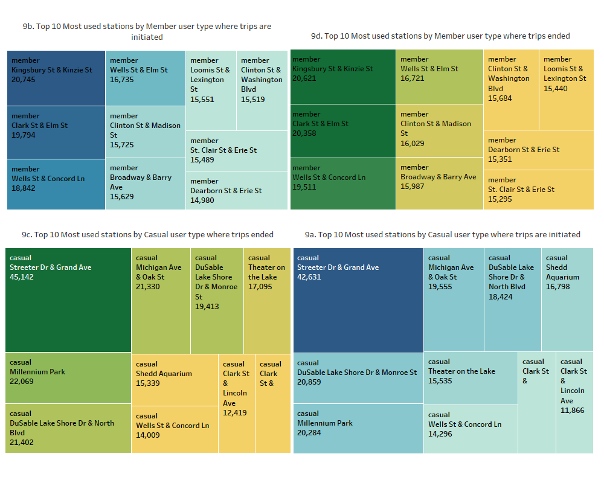

```r
knitr::include_graphics("Dashboard 2dn.png",error = FALSE)
```

# VI ACT

We will answer the key business question and provide recommendations based on our analysis to guide Cyclistic’s marketing strategy in this final phase.

**Summary of Analysis**

Based on my research, I discovered the following differences in the riding habits of casual and annual members:

**• Preferred bike type of users**

Electric and classic bikes are common among both users, while docked bikes are fairly used by casual riders only Annual members typically don’t.

**• Day of week users ride**

Casual riders ride more over the weekends (Friday, Saturday, and Sunday) while annual members ride more during the week (Tuesday, Wednesday, and Thursday)

**• Time of Day users ride**

**• Average Ride Length for both Member type**

Casual riders ride for longer than member riders, averaging 23 minutes and 22 seconds per ride compared to 12 minutes and 57 seconds for annual members.

**• How many rides got started and ended immediately**

Trips were initiated and canceled immediately between both user types, with member riders canceling a total of 27,601 trips and casual users canceling 14,894 trips.

**• To know which top 10 stations are mostly used to start/end trip and by either user type excluding unused trips.**

We reveal the top 10 stations that are popular among both user types by analyzing user behavior patterns such as where trips are started and ended the most. Our findings show that Streeter Dr & Grand Ave are the most popular starting and ending points for casual users, while Kingsbury St & Kinzie St are the most popular starting and ending points for member users.

**Recommendations**

• An annual membership subscription discount should be offered exclusively to docked bikes in order to attract more annual users to the bike type.

•. A campaign should be launched to reward annual members who ride for longer periods of time. For example, the longer you ride, the more points you earn to win prizes such as free rides, gift cards, and so on.

• Marketing campaigns should be targeted for the busiest casual rider days (Friday, Saturday, and Sunday) and busiest hours to reach the most riders (during the day).

• Some type of discounted offer can be assigned to stations outside the top ten most used in order to attract more usage within the zones, and some type of reward can be assigned to the most used stations in order to ensure continuous usage.

• Targeted premium features can be offered to persuade casual users to join as members to meet their specific fun goals for riding mostly on weekends.